# Melbourne housing analysis

The information offered is from the city of Melbourne and includes the various characteristics of homes there as well as the areas where they are situated. The objective is to conduct a thorough analysis of this dataset and offer insightful information that will help one of Melbourne's top real estate firms make the process of buying and selling real estate easier. As a data scientist, I perform exploratory data analysis and produce beneficial insights for the company's stakeholders.

## Data Description:

The detailed data dictionary is given below:

- Suburb - Suburb in which the property is located
- Rooms - Number of rooms in the property
- Type - Type of the property like
  - h - house,cottage,villa, semi,terrace,
  - t - townhouse,
  - u - unit, duplex
- SellerG - Name of the real estate agent who sold the property
- Date - Date on which the property was sold
- Distance - Distance of the property from CBD in kilometres. CBD is the central business district of the city.
- Postcode - Postcode of the area
- Bedroom - Number of bedrooms in the property
- Bathroom - Number of bathrooms in the property
- Car - Number of car parking spaces in the property
- Landsize - Size of the land in square metres
- BuildingArea - Size of the building in square metres
- YearBuilt - Year in which the building was built
- Regionname - Name of the region in which the property is located like Eastern Metropolitan, Western Metropolitan, Northern Victoria etc.
- Propertycount - Number of properties that are present in the suburb
- Price - price (in AUD) at which the property was sold

The dataset has been taken from kaggle :https://www.kaggle.com/datasets/saadmehar/melbourne-housing-fullcsv

**Importing necessary libraries**

```python
# Libraries to handle the dataset or to manipulate dataset
import numpy as np
import pandas as pd

# Libraries for data visualization
import matplotlib.pyplot as plt
import seaborn as sns
# to restrict the float value to 3 decimal places
pd.set_option('display.float_format', lambda x: '%.3f' % x)#lambda function to restrict any value x to 3decimal places
```

**load the dataset**

```python
data = pd.read_csv('C:/Users/Anagha/Downloads/archive (4)/Melbourne_housing_FULL.csv')# read_csv used to load the dataset
```

**View the first and last 5 rows of the dataset**

```python
data.head()# daa.head() displays the first 5 rows of the dataframe
```

|  | Suburb | Address | Rooms | Type | Price | Method | SellerG | Date | Distance | Postcode | ... | Bathroom | Car | Landsize | BuildingArea | YearBuilt | CouncilArea | Lattitude | Longtitude | Regionname | Propertycount |
| --- | --- | --- | --- | --- | --- | --- | --- | --- | --- | --- | --- | --- | --- | --- | --- | --- | --- | --- | --- | --- | --- |
| 0 | Abbotsford | 68 Studley St | 2 | h | NaN | SS | Jellis | 3/09/2016 | 2.500 | 3067.000 | ... | 1.000 | 1.000 | 126.000 | NaN | NaN | Yarra City Council | -37.801 | 144.996 | Northern Metropolitan | 4019.000 |
| 1 | Abbotsford | 85 Turner St | 2 | h | 1480000.000 | S | Biggin | 3/12/2016 | 2.500 | 3067.000 | ... | 1.000 | 1.000 | 202.000 | NaN | NaN | Yarra City Council | -37.800 | 144.998 | Northern Metropolitan | 4019.000 |
| 2 | Abbotsford | 25 Bloomburg St | 2 | h | 1035000.000 | S | Biggin | 4/02/2016 | 2.500 | 3067.000 | ... | 1.000 | 0.000 | 156.000 | 79.000 | 1900.000 | Yarra City Council | -37.808 | 144.993 | Northern Metropolitan | 4019.000 |
| 3 | Abbotsford | 18/659 Victoria St | 3 | u | NaN | VB | Rounds | 4/02/2016 | 2.500 | 3067.000 | ... | 2.000 | 1.000 | 0.000 | NaN | NaN | Yarra City Council | -37.811 | 145.012 | Northern Metropolitan | 4019.000 |
| 4 | Abbotsford | 5 Charles St | 3 | h | 1465000.000 | SP | Biggin | 4/03/2017 | 2.500 | 3067.000 | ... | 2.000 | 0.000 | 134.000 | 150.000 | 1900.000 | Yarra City Council | -37.809 | 144.994 | Northern Metropolitan | 4019.000 |

5 rows × 21 columns

```python
data.tail()# displays the last 5 rows of dataset
```

|  | Suburb | Address | Rooms | Type | Price | Method | SellerG | Date | Distance | Postcode | ... | Bathroom | Car | Landsize | BuildingArea | YearBuilt | CouncilArea | Lattitude | Longtitude | Regionname | Propertycount |
| --- | --- | --- | --- | --- | --- | --- | --- | --- | --- | --- | --- | --- | --- | --- | --- | --- | --- | --- | --- | --- | --- |
| 34852 | Yarraville | 13 Burns St | 4 | h | 1480000.000 | PI | Jas | 24/02/2018 | 6.300 | 3013.000 | ... | 1.000 | 3.000 | 593.000 | NaN | NaN | Maribyrnong City Council | -37.811 | 144.885 | Western Metropolitan | 6543.000 |
| 34853 | Yarraville | 29A Murray St | 2 | h | 888000.000 | SP | Sweeney | 24/02/2018 | 6.300 | 3013.000 | ... | 2.000 | 1.000 | 98.000 | 104.000 | 2018.000 | Maribyrnong City Council | -37.816 | 144.888 | Western Metropolitan | 6543.000 |
| 34854 | Yarraville | 147A Severn St | 2 | t | 705000.000 | S | Jas | 24/02/2018 | 6.300 | 3013.000 | ... | 1.000 | 2.000 | 220.000 | 120.000 | 2000.000 | Maribyrnong City Council | -37.823 | 144.879 | Western Metropolitan | 6543.000 |
| 34855 | Yarraville | 12/37 Stephen St | 3 | h | 1140000.000 | SP | hockingstuart | 24/02/2018 | 6.300 | 3013.000 | ... | NaN | NaN | NaN | NaN | NaN | Maribyrnong City Council | NaN | NaN | Western Metropolitan | 6543.000 |
| 34856 | Yarraville | 3 Tarrengower St | 2 | h | 1020000.000 | PI | RW | 24/02/2018 | 6.300 | 3013.000 | ... | 1.000 | 0.000 | 250.000 | 103.000 | 1930.000 | Maribyrnong City Council | -37.818 | 144.894 | Western Metropolitan | 6543.000 |

5 rows × 21 columns

**shape of the dataset**

```python
# checking shape of the data
print("There are", data.shape[0], 'rows and', data.shape[1], "columns")
```

```
There are 34857 rows and 21 columns
```

**Checking the data types of the columns for the dataset**

```python
data.dtypes#to find the data types
```

```
Suburb            object
Address           object
Rooms              int64
Type              object
Price            float64
Method            object
SellerG           object
Date              object
Distance         float64
Postcode         float64
Bedroom2         float64
Bathroom         float64
Car              float64
Landsize         float64
BuildingArea     float64
YearBuilt        float64
CouncilArea       object
Lattitude        float64
Longtitude       float64
Regionname        object
Propertycount    float64
dtype: object
```

```python
data.info()# this is another way to find the datatypes and data set's information
```

```
<class 'pandas.core.frame.DataFrame'>
RangeIndex: 34857 entries, 0 to 34856
Data columns (total 21 columns):
 #   Column         Non-Null Count  Dtype
---  ------         --------------  -----
 0   Suburb         34857 non-null  object
 1   Address        34857 non-null  object
 2   Rooms          34857 non-null  int64
 3   Type           34857 non-null  object
 4   Price          27247 non-null  float64
 5   Method         34857 non-null  object
 6   SellerG        34857 non-null  object
 7   Date           34857 non-null  object
 8   Distance       34856 non-null  float64
 9   Postcode       34856 non-null  float64
 10  Bedroom2       26640 non-null  float64
 11  Bathroom       26631 non-null  float64
 12  Car            26129 non-null  float64
 13  Landsize       23047 non-null  float64
 14  BuildingArea   13742 non-null  float64
 15  YearBuilt      15551 non-null  float64
 16  CouncilArea    34854 non-null  object
 17  Lattitude      26881 non-null  float64
 18  Longtitude     26881 non-null  float64
 19  Regionname     34854 non-null  object
 20  Propertycount  34854 non-null  float64
dtypes: float64(12), int64(1), object(8)
memory usage: 5.6+ MB
```

- There are 13 numerical columns in the data and 8 object type columns.
- Date column is being read as object type column but it should be in date-time format.

```python
# changing the data type of Date column
data['Date'] = pd.to_datetime(data['Date'])
```

```python
# let's check the data type of columns again
data.info()
```

```
<class 'pandas.core.frame.DataFrame'>
RangeIndex: 34857 entries, 0 to 34856
Data columns (total 21 columns):
 #   Column         Non-Null Count  Dtype
---  ------         --------------  -----
 0   Suburb         34857 non-null  object
 1   Address        34857 non-null  object
 2   Rooms          34857 non-null  int64
 3   Type           34857 non-null  object
 4   Price          27247 non-null  float64
 5   Method         34857 non-null  object
 6   SellerG        34857 non-null  object
 7   Date           34857 non-null  datetime64[ns]
 8   Distance       34856 non-null  float64
 9   Postcode       34856 non-null  float64
 10  Bedroom2       26640 non-null  float64
 11  Bathroom       26631 non-null  float64
 12  Car            26129 non-null  float64
 13  Landsize       23047 non-null  float64
 14  BuildingArea   13742 non-null  float64
 15  YearBuilt      15551 non-null  float64
 16  CouncilArea    34854 non-null  object
 17  Lattitude      26881 non-null  float64
 18  Longtitude     26881 non-null  float64
 19  Regionname     34854 non-null  object
 20  Propertycount  34854 non-null  float64
dtypes: datetime64[ns](1), float64(12), int64(1), object(7)
memory usage: 5.6+ MB
```

- now we can see that the datatype of the Date field has been changed to datetime
- We observe that some columns have less entries that other columns (less than 34857 rows) which indicates the presence of missing values in the data.

**Checking for missing values in the data**

```python
data.isnull().sum()# isnull() is used to find if there is any null value, here we are finding summ of null values for each coloumn
```

```
Suburb               0
Address              0
Rooms                0
Type                 0
Price             7610
Method               0
SellerG              0
Date                 0
Distance             1
Postcode             1
Bedroom2          8217
Bathroom          8226
Car               8728
Landsize         11810
BuildingArea     21115
YearBuilt        19306
CouncilArea          3
Lattitude         7976
Longtitude        7976
Regionname           3
Propertycount        3
dtype: int64
```

- There are missing values in 14 columns of the data.
- We will treat these missing values after understanding the distributions of features in the data, the relationships that exist in the data. This will help us replace these values more effectively.

**Checking for duplicate entries in the dataset**

```python
data.duplicated().sum()# to check if the is any duplicated entries in the data frame
```

```
1
```

- There is only 1 duplicate entry in the dataset. Let's remove them.

```python
# dropping duplicate entries from the data
data.drop_duplicates(inplace=True)

# resetting the index of data frame since 1 row will be removed
data.reset_index(drop=True,inplace=True)
```

**Let's check the statistical summary of the data.**

```python
data.describe()# describe is used to get the data of the numerical coloumns we get mean ,standard deviation etc.
```

|  | Rooms | Price | Distance | Postcode | Bedroom2 | Bathroom | Car | Landsize | BuildingArea | YearBuilt | Lattitude | Longtitude | Propertycount |
| --- | --- | --- | --- | --- | --- | --- | --- | --- | --- | --- | --- | --- | --- |
| count | 34856.000 | 27247.000 | 34855.000 | 34855.000 | 26639.000 | 26630.000 | 26128.000 | 23046.000 | 13741.000 | 15550.000 | 26880.000 | 26880.000 | 34853.000 |
| mean | 3.031 | 1050173.345 | 11.185 | 3116.062 | 3.085 | 1.625 | 1.729 | 593.607 | 160.252 | 1965.288 | -37.811 | 145.002 | 7572.963 |
| std | 0.970 | 641467.130 | 6.789 | 109.025 | 0.981 | 0.724 | 1.011 | 3398.915 | 401.281 | 37.328 | 0.090 | 0.120 | 4428.132 |
| min | 1.000 | 85000.000 | 0.000 | 3000.000 | 0.000 | 0.000 | 0.000 | 0.000 | 0.000 | 1196.000 | -38.190 | 144.424 | 83.000 |
| 25% | 2.000 | 635000.000 | 6.400 | 3051.000 | 2.000 | 1.000 | 1.000 | 224.000 | 102.000 | 1940.000 | -37.863 | 144.934 | 4385.000 |
| 50% | 3.000 | 870000.000 | 10.300 | 3103.000 | 3.000 | 2.000 | 2.000 | 521.000 | 136.000 | 1970.000 | -37.808 | 145.008 | 6763.000 |
| 75% | 4.000 | 1295000.000 | 14.000 | 3156.000 | 4.000 | 2.000 | 2.000 | 670.000 | 188.000 | 2000.000 | -37.754 | 145.072 | 10412.000 |
| max | 16.000 | 11200000.000 | 48.100 | 3978.000 | 30.000 | 12.000 | 26.000 | 433014.000 | 44515.000 | 2106.000 | -37.390 | 145.526 | 21650.000 |

```python
# let's check the total number of unique values in the Postcode column
data['Postcode'].nunique()
```

```
211
```

- There are a total of 211 different postcodes in the data.

**Let's check the unique count of categorical levels in each column**

```python
# Making a list of all categorical variables
cat_cols =  ['Suburb', 'Type', 'SellerG', 'Regionname']

# Printing the count of unique categorical levels in each column
for column in cat_cols:
    print(data[column].value_counts())# here it counts unique values of each coloumn one by one.
    print("-" * 50)
```

```
Reservoir         844
Bentleigh East    583
Richmond          552
Glen Iris         491
Preston           485
                 ...
viewbank            1
Wandin North        1
Menzies Creek       1
Guys Hill           1
Belgrave            1
Name: Suburb, Length: 351, dtype: int64
--------------------------------------------------
h    23980
u     7297
t     3579
Name: Type, dtype: int64
--------------------------------------------------
Jellis                  3358
Nelson                  3236
Barry                   3235
hockingstuart           2623
Marshall                2027
                        ...
T                          1
Unity                      1
Zahn                       1
PSP                        1
hockingstuart/Cayzer       1
Name: SellerG, Length: 388, dtype: int64
--------------------------------------------------
Southern Metropolitan         11836
Northern Metropolitan          9557
Western Metropolitan           6799
Eastern Metropolitan           4376
South-Eastern Metropolitan     1739
Eastern Victoria                228
Northern Victoria               203
Western Victoria                115
Name: Regionname, dtype: int64
--------------------------------------------------
```

**Observations**

# **univariate analysis to get to know each coloumns**

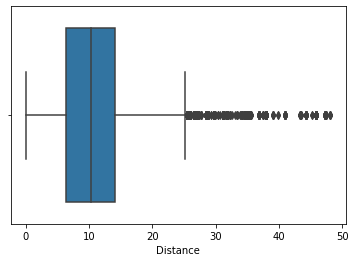

```python
#using seaborn library to plot the boxplot for distance coloumn
sns.boxplot(data=data,x='Distance')
plt.show()
```

- There are many outliers present in this column.
- Values over 25 kilometers are shown as outliers in the boxplot, showing that numerous properties are at least 25 kilometers from the center.

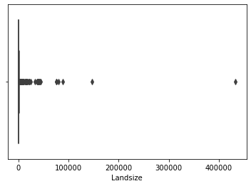

```python
sns.boxplot(data=data,x='Landsize')
plt.show()
```

- There are many outliers present in this column. Some properties have a landsize of more than 40000 sq meters. These value seems to be very high.

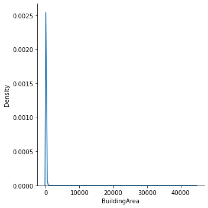

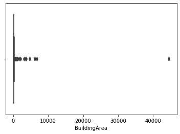

```python
sns.displot(data=data,x='BuildingArea',kind='kde')
plt.show()
sns.boxplot(data=data,x='BuildingArea')
plt.show()
```

- The distribution of BuildingArea is similar to Landsize that is right skewed.
- It has many outliers.
- There are values above 4000 sq meters which is high.

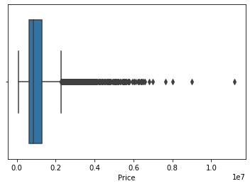

```python
sns.boxplot(data=data,x='Price')#using seaborn library to plot the boxplot for price coloumn
plt.show()
```

- There are many outliers in this variable and the values above 2000000 are being represented as outliers by the boxplot.

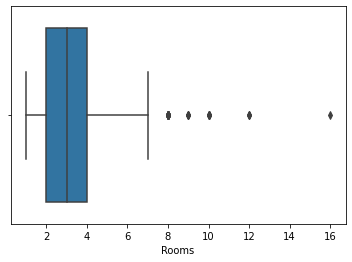

```python
sns.boxplot(data=data,x='Rooms')#using seaborn library to plot the boxplot for rooms coloumn
plt.show()
```

- Properties with more than 7 rooms are being represented as outliers by the boxplot.

```python
data.loc[data['Rooms']>7].shape #gives the number of rooms that have more than 7 rooms.
```

```
(33, 21)
```

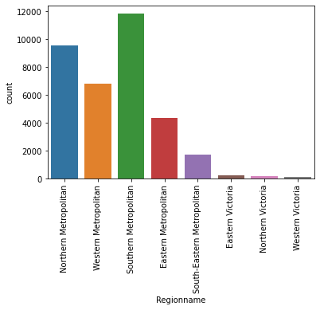

```python
sns.countplot(data=data,x='Regionname')#from seaborn library using countplot
plt.xticks(rotation=90)#gives the naming and rotating them to 90 degree
plt.show()#shows an image
```

- Eastern, Northern, and Western Victoria have very less number of properties.
- Southern and Northern Metropolitan have the most number of properties.

**More living space, more rooms, more bedrooms, and more baths often translate into higher selling prices for properties. Let's examine the relationship between a property's cost and the total number of rooms**.

```python
# creating a column with a sum of number of rooms, bedrooms, bathrooms, and car parking spaces
data['Total Space'] = data['Rooms'] + data['Bedroom2'] + data['Bathroom'] + data['Car']
data.head()
```

|  | Suburb | Address | Rooms | Type | Price | Method | SellerG | Date | Distance | Postcode | ... | Car | Landsize | BuildingArea | YearBuilt | CouncilArea | Lattitude | Longtitude | Regionname | Propertycount | Total Space |
| --- | --- | --- | --- | --- | --- | --- | --- | --- | --- | --- | --- | --- | --- | --- | --- | --- | --- | --- | --- | --- | --- |
| 0 | Abbotsford | 68 Studley St | 2 | h | NaN | SS | Jellis | 2016-03-09 | 2.500 | 3067.000 | ... | 1.000 | 126.000 | NaN | NaN | Yarra City Council | -37.801 | 144.996 | Northern Metropolitan | 4019.000 | 6.000 |
| 1 | Abbotsford | 85 Turner St | 2 | h | 1480000.000 | S | Biggin | 2016-03-12 | 2.500 | 3067.000 | ... | 1.000 | 202.000 | NaN | NaN | Yarra City Council | -37.800 | 144.998 | Northern Metropolitan | 4019.000 | 6.000 |
| 2 | Abbotsford | 25 Bloomburg St | 2 | h | 1035000.000 | S | Biggin | 2016-04-02 | 2.500 | 3067.000 | ... | 0.000 | 156.000 | 79.000 | 1900.000 | Yarra City Council | -37.808 | 144.993 | Northern Metropolitan | 4019.000 | 5.000 |
| 3 | Abbotsford | 18/659 Victoria St | 3 | u | NaN | VB | Rounds | 2016-04-02 | 2.500 | 3067.000 | ... | 1.000 | 0.000 | NaN | NaN | Yarra City Council | -37.811 | 145.012 | Northern Metropolitan | 4019.000 | 9.000 |
| 4 | Abbotsford | 5 Charles St | 3 | h | 1465000.000 | SP | Biggin | 2017-04-03 | 2.500 | 3067.000 | ... | 0.000 | 134.000 | 150.000 | 1900.000 | Yarra City Council | -37.809 | 144.994 | Northern Metropolitan | 4019.000 | 8.000 |

5 rows × 22 columns

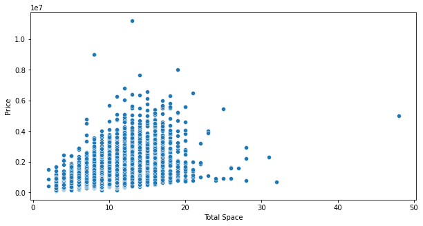

```python
plt.figure(figsize=(10,5))
sns.scatterplot(data=data,x='Total Space',y='Price')#plot a scatterplot
plt.show()
```

```python
# let's first calculate the age of a property from the year it was built in to see how the prices vary with it
year_at_sale = data['Date'].dt.year
year_at_sale
```

```
0        2016
1        2016
2        2016
3        2016
4        2017
         ...
34851    2018
34852    2018
34853    2018
34854    2018
34855    2018
Name: Date, Length: 34856, dtype: int64
```

```python
np.max(year_at_sale)#finding maximum year of sale
```

```
2018
```

```python
data['AgeofProp'] = year_at_sale - data['YearBuilt']#finding the age of the property
```

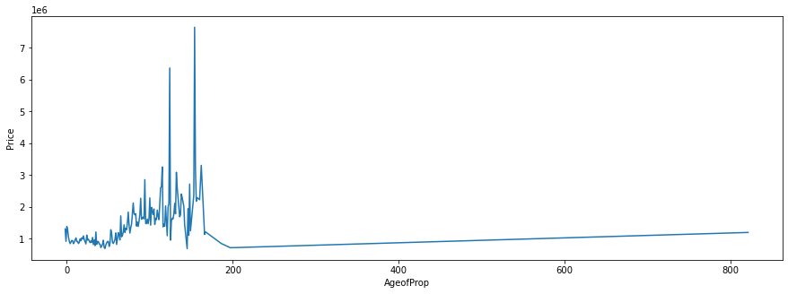

```python
plt.figure(figsize=(15,5))
sns.lineplot(data=data,x='AgeofProp',y='Price',ci=None)
plt.show()
```

- We observe an increasing trend indicating the properties which are older have higher selling prices.
- The customers who wish to live in vintage properties might have to spend more money.

### Treating the missing values in the dataset

```python
data.shape[0] # will give us the number of rows in the dataset
data.isnull().sum()
```

```
Suburb               0
Address              0
Rooms                0
Type                 0
Price             7609
Method               0
SellerG              0
Date                 0
Distance             1
Postcode             1
Bedroom2          8217
Bathroom          8226
Car               8728
Landsize         11810
BuildingArea     21115
YearBuilt        19306
CouncilArea          3
Lattitude         7976
Longtitude        7976
Regionname           3
Propertycount        3
Total Space       8728
AgeofProp        19306
dtype: int64
```

**Missing value treatment for Distance column**

```python
# checking all the information of other variables where Distance is null
data.loc[data['Distance'].isnull()==True]
```

|  | Suburb | Address | Rooms | Type | Price | Method | SellerG | Date | Distance | Postcode | ... | Landsize | BuildingArea | YearBuilt | CouncilArea | Lattitude | Longtitude | Regionname | Propertycount | Total Space | AgeofProp |
| --- | --- | --- | --- | --- | --- | --- | --- | --- | --- | --- | --- | --- | --- | --- | --- | --- | --- | --- | --- | --- | --- |
| 29482 | Fawkner Lot | 1/3 Brian St | 3 | h | 616000.000 | SP | Brad | 2018-06-01 | NaN | NaN | ... | NaN | NaN | NaN | NaN | NaN | NaN | NaN | NaN | NaN | NaN |

1 rows × 23 columns

```python
data.loc[data['Suburb']=='Fawkner Lot']# checking the information of a rows whose suburb value is equal to fawkner lot
```

|  | Suburb | Address | Rooms | Type | Price | Method | SellerG | Date | Distance | Postcode | ... | Landsize | BuildingArea | YearBuilt | CouncilArea | Lattitude | Longtitude | Regionname | Propertycount | Total Space | AgeofProp |
| --- | --- | --- | --- | --- | --- | --- | --- | --- | --- | --- | --- | --- | --- | --- | --- | --- | --- | --- | --- | --- | --- |
| 29482 | Fawkner Lot | 1/3 Brian St | 3 | h | 616000.000 | SP | Brad | 2018-06-01 | NaN | NaN | ... | NaN | NaN | NaN | NaN | NaN | NaN | NaN | NaN | NaN | NaN |

1 rows × 23 columns

- We see that there is only one data entry for the Fawkner Lot suburb. hence we can remove the coloumn.

```python
# adding the index value of the row in data.drop() function
data = data.drop(29482).reset_index(drop=True)
```

```python
data.isnull().sum()
```

```
Suburb               0
Address              0
Rooms                0
Type                 0
Price             7609
Method               0
SellerG              0
Date                 0
Distance             0
Postcode             0
Bedroom2          8216
Bathroom          8225
Car               8727
Landsize         11809
BuildingArea     21114
YearBuilt        19305
CouncilArea          2
Lattitude         7975
Longtitude        7975
Regionname           2
Propertycount        2
Total Space       8727
AgeofProp        19305
dtype: int64
```

```python
# extracting all the information of other variable where bedroom is null
data.loc[data['Bedroom2'].isnull()==True]
```

|  | Suburb | Address | Rooms | Type | Price | Method | SellerG | Date | Distance | Postcode | ... | Landsize | BuildingArea | YearBuilt | CouncilArea | Lattitude | Longtitude | Regionname | Propertycount | Total Space | AgeofProp |
| --- | --- | --- | --- | --- | --- | --- | --- | --- | --- | --- | --- | --- | --- | --- | --- | --- | --- | --- | --- | --- | --- |
| 15 | Abbotsford | 217 Langridge St | 3 | h | 1000000.000 | S | Jellis | 2016-08-10 | 2.500 | 3067.000 | ... | NaN | NaN | NaN | Yarra City Council | NaN | NaN | Northern Metropolitan | 4019.000 | NaN | NaN |
| 16 | Abbotsford | 18a Mollison St | 2 | t | 745000.000 | S | Jellis | 2016-08-10 | 2.500 | 3067.000 | ... | NaN | NaN | NaN | Yarra City Council | NaN | NaN | Northern Metropolitan | 4019.000 | NaN | NaN |
| 19 | Abbotsford | 403/609 Victoria St | 2 | u | 542000.000 | S | Dingle | 2016-08-10 | 2.500 | 3067.000 | ... | NaN | NaN | NaN | Yarra City Council | NaN | NaN | Northern Metropolitan | 4019.000 | NaN | NaN |
| 21 | Abbotsford | 25/84 Trenerry Cr | 2 | u | 760000.000 | SP | Biggin | 2016-10-12 | 2.500 | 3067.000 | ... | NaN | NaN | NaN | Yarra City Council | NaN | NaN | Northern Metropolitan | 4019.000 | NaN | NaN |
| 22 | Abbotsford | 106/119 Turner St | 1 | u | 481000.000 | SP | Purplebricks | 2016-10-12 | 2.500 | 3067.000 | ... | NaN | NaN | NaN | Yarra City Council | NaN | NaN | Northern Metropolitan | 4019.000 | NaN | NaN |
| ... | ... | ... | ... | ... | ... | ... | ... | ... | ... | ... | ... | ... | ... | ... | ... | ... | ... | ... | ... | ... | ... |
| 34836 | Williamstown | 11/81 Melbourne Rd | 2 | u | 450000.000 | SP | Raine | 2018-02-24 | 6.800 | 3016.000 | ... | NaN | NaN | NaN | Hobsons Bay City Council | NaN | NaN | Western Metropolitan | 6380.000 | NaN | NaN |
| 34837 | Williamstown | 24/18 Station Rd | 2 | u | 475000.000 | SP | Greg | 2018-02-24 | 6.800 | 3016.000 | ... | NaN | NaN | NaN | Hobsons Bay City Council | NaN | NaN | Western Metropolitan | 6380.000 | NaN | NaN |
| 34838 | Williamstown | 3/2 Thompson St | 2 | u | 520000.000 | VB | Raine | 2018-02-24 | 6.800 | 3016.000 | ... | NaN | NaN | NaN | Hobsons Bay City Council | NaN | NaN | Western Metropolitan | 6380.000 | NaN | NaN |
| 34842 | Windsor | 4/16 Lewisham Rd | 1 | u | 440000.000 | SP | Biggin | 2018-02-24 | 4.600 | 3181.000 | ... | NaN | NaN | NaN | Port Phillip City Council | NaN | NaN | Southern Metropolitan | 4380.000 | NaN | NaN |
| 34853 | Yarraville | 12/37 Stephen St | 3 | h | 1140000.000 | SP | hockingstuart | 2018-02-24 | 6.300 | 3013.000 | ... | NaN | NaN | NaN | Maribyrnong City Council | NaN | NaN | Western Metropolitan | 6543.000 | NaN | NaN |

8216 rows × 23 columns

We can see from the above set of data if bedroom is null the bathroom car landsize is also null so we have to check group of data which are missing in all coloumns commonly

```python
data.loc[data['Bedroom2'].isnull()==True,'Bathroom'].value_counts(dropna=False)#checking if bedroom is null how many records have bathroom also null
```

```
NaN    8216
Name: Bathroom, dtype: int64
```

```python
data.loc[data['Bedroom2'].isnull()==True,'Car'].value_counts(dropna=False)#checking if bedroom is null how many records have car also null
```

```
NaN    8216
Name: Car, dtype: int64
```

```python
data.loc[data['Bedroom2'].isnull()==True,'Landsize'].value_counts(dropna=False)#checking if bedroom is null how many records have landsize also null
```

```
NaN        8209
338.000       1
446.000       1
549.000       1
239.000       1
128.000       1
250.000       1
594.000       1
Name: Landsize, dtype: int64
```

```python
data.loc[data['Bedroom2'].isnull()==True,'BuildingArea'].value_counts(dropna=False)#checking if bedroom is null how many records have buildingarea also null
```

```
NaN    8216
Name: BuildingArea, dtype: int64
```

```python
data.loc[data['Bedroom2'].isnull()==True,'YearBuilt'].value_counts(dropna=False)#checking if bedroom is null how many records have yearbuilt also null
```

```
NaN    8216
Name: YearBuilt, dtype: int64
```

- There seems to be a strong pattern in missing values, as wherever the Bedroom column has missing data the other columns like Bathroom, Car, Landsize, BuildingArea, and YearBuilt also have missing values.
- Let's see if the missing data has some pattern in suburbs, and regions of properties.

**Missing value treatment for Bedroom, Bathroom, and Car columns**

- One of the approaches to treat the missing values of these columns would be to group the data on the basis of Region and Type of the property to get a better idea of the average number of bedrooms, bathrooms, and car parking spaces.
- It is more likely that a property of certain type in a given region would have similar number of bedrooms, bathrooms, and car parking spaces.

```python
# checking the average number of bedrooms, bathrooms, and car parking spaces in a region
data.groupby(['Regionname','Type'])[['Bedroom2','Bathroom','Car']].mean()
```

| Regionname | Type | Bedroom2 | Bathroom | Car |
| --- | --- | --- | --- | --- |
| Eastern Metropolitan | h | 3.578 | 1.833 | 1.943 |
|  | t | 3.031 | 1.877 | 1.636 |
|  | u | 2.382 | 1.275 | 1.300 |
| Eastern Victoria | h | 3.582 | 1.879 | 2.124 |
|  | t | 3.000 | 2.000 | 1.667 |
|  | u | 2.750 | 1.000 | 1.500 |
| Northern Metropolitan | h | 3.121 | 1.483 | 1.686 |
|  | t | 2.572 | 1.639 | 1.362 |
|  | u | 1.864 | 1.168 | 1.087 |
| Northern Victoria | h | 3.558 | 1.901 | 2.229 |
|  | t | NaN | NaN | NaN |
|  | u | 3.000 | 2.000 | 2.000 |
| South-Eastern Metropolitan | h | 3.500 | 1.721 | 2.121 |
|  | t | 2.961 | 1.855 | 1.711 |
|  | u | 2.341 | 1.227 | 1.352 |
| Southern Metropolitan | h | 3.427 | 1.882 | 1.888 |
|  | t | 3.031 | 2.017 | 1.787 |
|  | u | 1.939 | 1.194 | 1.141 |
| Western Metropolitan | h | 3.267 | 1.597 | 1.913 |
|  | t | 2.881 | 1.826 | 1.531 |
|  | u | 2.073 | 1.198 | 1.131 |
| Western Victoria | h | 3.356 | 1.462 | 2.090 |
|  | u | NaN | NaN | NaN |

We will use fillna() function and transform method of pandas to impute the missing values. Here the room space and car spaces majorly depends on region and type of house hence we group the room space with respect to regionname and type of house and we impute mean values

```python
# replacing missing values in Bedroom column with its mean value
data['Bedroom2'] = data['Bedroom2'].fillna(value = data.groupby(['Regionname','Type'])['Bedroom2'].transform('mean'))
```

```python
# replacing missing values in Bathroom column with its mean value
data['Bathroom'] = data['Bathroom'].fillna(value = data.groupby(['Regionname','Type'])['Bathroom'].transform('mean'))
```

```python
# replacing missing values in Car column with its mean value
data['Car'] = data['Car'].fillna(value = data.groupby(['Regionname','Type'])['Car'].transform('mean'))
```

```python
# checking if all the missing values were imputed in Bedroom, Bathroom, and Car columns
data.isnull().sum()
```

```
Suburb               0
Address              0
Rooms                0
Type                 0
Price             7609
Method               0
SellerG              0
Date                 0
Distance             0
Postcode             0
Bedroom2             5
Bathroom             5
Car                  5
Landsize         11809
BuildingArea     21114
YearBuilt        19305
CouncilArea          2
Lattitude         7975
Longtitude        7975
Regionname           2
Propertycount        2
Total Space       8727
AgeofProp        19305
dtype: int64
```

```python
data2=data.loc[data['Car'].isnull()==True]

for index, row in data2.iterrows():
  data.drop(index, inplace=True)
data.reset_index(drop=True, inplace=True)
```

The above values contain the regionname or the type as Nan hence drop these rows

```python
data.isnull().sum()
```

```
Suburb               0
Address              0
Rooms                0
Type                 0
Price             7609
Method               0
SellerG              0
Date                 0
Distance             0
Postcode             0
Bedroom2             0
Bathroom             0
Car                  0
Landsize         11804
BuildingArea     21109
YearBuilt        19300
CouncilArea          0
Lattitude         7970
Longtitude        7970
Regionname           0
Propertycount        0
Total Space       8722
AgeofProp        19300
dtype: int64
```

**Missing values of Total Space column**

```python
# as we created this coloumn for analysis remove Total Space column
data.drop('Total Space',axis=1,inplace=True)
data.drop('AgeofProp',axis=1,inplace=True)
```

```python
data.groupby(['Regionname','Type'])[['Landsize']].mean() #based on the regionname and type of properties finding the mean of landsize
```

| Regionname | Type | Landsize |
| --- | --- | --- |
| Eastern Metropolitan | h | 746.675 |
|  | t | 265.184 |
|  | u | 334.194 |
| Eastern Victoria | h | 2387.626 |
|  | t | 193.000 |
|  | u | 317.500 |
| Northern Metropolitan | h | 564.831 |
|  | t | 318.401 |
|  | u | 478.405 |
| Northern Victoria | h | 4065.523 |
|  | u | 315.000 |
| South-Eastern Metropolitan | h | 687.662 |
|  | t | 299.275 |
|  | u | 340.320 |
| Southern Metropolitan | h | 582.439 |
|  | t | 317.910 |
|  | u | 474.881 |
| Western Metropolitan | h | 565.367 |
|  | t | 251.313 |
|  | u | 576.397 |
| Western Victoria | h | 1099.458 |

```python
#replacing the missing data with its mean value
data['Landsize'] = data['Landsize'].fillna(value = data.groupby(['Regionname','Type'])['Landsize'].transform('mean'))
```

```python
# checking if all the missing values were replaced in Landsize column
data.isnull().sum()
```

```
Suburb               0
Address              0
Rooms                0
Type                 0
Price             7609
Method               0
SellerG              0
Date                 0
Distance             0
Postcode             0
Bedroom2             0
Bathroom             0
Car                  0
Landsize             0
BuildingArea     21109
YearBuilt        19300
CouncilArea          0
Lattitude         7970
Longtitude        7970
Regionname           0
Propertycount        0
dtype: int64
```

```python
data.loc[data['Price'].isnull()==True]
```

|  | Suburb | Address | Rooms | Type | Price | Method | SellerG | Date | Distance | Postcode | ... | Bathroom | Car | Landsize | BuildingArea | YearBuilt | CouncilArea | Lattitude | Longtitude | Regionname | Propertycount |
| --- | --- | --- | --- | --- | --- | --- | --- | --- | --- | --- | --- | --- | --- | --- | --- | --- | --- | --- | --- | --- | --- |
| 0 | Abbotsford | 68 Studley St | 2 | h | NaN | SS | Jellis | 2016-03-09 | 2.500 | 3067.000 | ... | 1.000 | 1.000 | 126.000 | NaN | NaN | Yarra City Council | -37.801 | 144.996 | Northern Metropolitan | 4019.000 |
| 3 | Abbotsford | 18/659 Victoria St | 3 | u | NaN | VB | Rounds | 2016-04-02 | 2.500 | 3067.000 | ... | 2.000 | 1.000 | 0.000 | NaN | NaN | Yarra City Council | -37.811 | 145.012 | Northern Metropolitan | 4019.000 |
| 7 | Abbotsford | 16 Maugie St | 4 | h | NaN | SN | Nelson | 2016-06-08 | 2.500 | 3067.000 | ... | 2.000 | 2.000 | 400.000 | 220.000 | 2006.000 | Yarra City Council | -37.797 | 144.996 | Northern Metropolitan | 4019.000 |
| 8 | Abbotsford | 53 Turner St | 2 | h | NaN | S | Biggin | 2016-06-08 | 2.500 | 3067.000 | ... | 1.000 | 2.000 | 201.000 | NaN | 1900.000 | Yarra City Council | -37.800 | 144.997 | Northern Metropolitan | 4019.000 |
| 9 | Abbotsford | 99 Turner St | 2 | h | NaN | S | Collins | 2016-06-08 | 2.500 | 3067.000 | ... | 2.000 | 1.000 | 202.000 | NaN | 1900.000 | Yarra City Council | -37.800 | 144.999 | Northern Metropolitan | 4019.000 |
| ... | ... | ... | ... | ... | ... | ... | ... | ... | ... | ... | ... | ... | ... | ... | ... | ... | ... | ... | ... | ... | ... |
| 34822 | West Melbourne | 9/11 Anderson St | 3 | u | NaN | S | hockingstuart | 2018-02-24 | 3.100 | 3003.000 | ... | 1.168 | 1.087 | 478.405 | NaN | NaN | Melbourne City Council | NaN | NaN | Northern Metropolitan | 2230.000 |
| 34827 | Wheelers Hill | 112 Jells Rd | 4 | h | NaN | PN | Harcourts | 2018-02-24 | 16.700 | 3150.000 | ... | 2.000 | 2.000 | 714.000 | NaN | NaN | Monash City Council | -37.903 | 145.190 | South-Eastern Metropolitan | 7392.000 |
| 34828 | Wheelers Hill | 20 Mill Ct | 3 | h | NaN | S | Barry | 2018-02-24 | 16.700 | 3150.000 | ... | 2.000 | 2.000 | 677.000 | NaN | NaN | Monash City Council | -37.919 | 145.191 | South-Eastern Metropolitan | 7392.000 |
| 34838 | Windsor | 13 Mary St | 4 | h | NaN | W | Jellis | 2018-02-24 | 4.600 | 3181.000 | ... | 3.000 | 2.000 | 279.000 | 237.000 | 2009.000 | Port Phillip City Council | -37.854 | 144.997 | Southern Metropolitan | 4380.000 |
| 34843 | Wollert | 15 Rockgarden Wy | 3 | h | NaN | SP | LJ | 2018-02-24 | 25.500 | 3750.000 | ... | 2.000 | 2.000 | 268.000 | 135.000 | 2016.000 | Whittlesea City Council | -37.611 | 145.043 | Northern Metropolitan | 2940.000 |

7609 rows × 21 columns

```python
data.groupby(['Regionname','Type'])[['Price']].mean()
```

| Regionname | Type | Price |
| --- | --- | --- |
| Eastern Metropolitan | h | 1197360.101 |
|  | t | 927265.156 |
|  | u | 705566.246 |
| Eastern Victoria | h | 722405.547 |
|  | t | 665000.000 |
|  | u | 477200.000 |
| Northern Metropolitan | h | 975948.115 |
|  | t | 728163.400 |
|  | u | 570048.846 |
| Northern Victoria | h | 620095.679 |
|  | u | 553000.000 |
| South-Eastern Metropolitan | h | 934607.256 |
|  | t | 858741.597 |
|  | u | 570781.081 |
| Southern Metropolitan | h | 1848269.396 |
|  | t | 1224860.144 |
|  | u | 690872.641 |
| Western Metropolitan | h | 911765.855 |
|  | t | 731762.019 |
|  | u | 506385.873 |
| Western Victoria | h | 435747.340 |

```python
# replacing the missing data with its mean price based on region and type of the house
data['Price'] = data['Price'].fillna(value = data.groupby(['Regionname','Type'])['Price'].transform('mean'))
```

```python
# checking if all the missing values were replaced in price column
data.isnull().sum()
```

```
Suburb               0
Address              0
Rooms                0
Type                 0
Price                0
Method               0
SellerG              0
Date                 0
Distance             0
Postcode             0
Bedroom2             0
Bathroom             0
Car                  0
Landsize             0
BuildingArea     21109
YearBuilt        19300
CouncilArea          0
Lattitude         7970
Longtitude        7970
Regionname           0
Propertycount        0
dtype: int64
```

```python
# checking the average number of bedrooms, bathrooms, and car parking spaces in a region
data.groupby(['Regionname'])[['Lattitude','Longtitude']].mean()
```

| Regionname | Lattitude | Longtitude |
| --- | --- | --- |
| Eastern Metropolitan | -37.798 | 145.145 |
| Eastern Victoria | -37.935 | 145.329 |
| Northern Metropolitan | -37.736 | 144.984 |
| Northern Victoria | -37.589 | 144.847 |
| South-Eastern Metropolitan | -37.998 | 145.153 |
| Southern Metropolitan | -37.867 | 145.035 |
| Western Metropolitan | -37.784 | 144.845 |
| Western Victoria | -37.695 | 144.567 |

```python
# grouping data on region and type of property
# finding the median of Lattitude and logtitude for each group and replacing the missing data with it
data['Lattitude'] = data['Lattitude'].fillna(value = data.groupby(['Regionname'])['Lattitude'].transform('mean'))
data['Longtitude'] = data['Longtitude'].fillna(value = data.groupby(['Regionname'])['Longtitude'].transform('mean'))
```

```python
# checking if all the missing values were replaced column
data.isnull().sum()
```

```
Suburb               0
Address              0
Rooms                0
Type                 0
Price                0
Method               0
SellerG              0
Date                 0
Distance             0
Postcode             0
Bedroom2             0
Bathroom             0
Car                  0
Landsize             0
BuildingArea     21109
YearBuilt        19300
CouncilArea          0
Lattitude            0
Longtitude           0
Regionname           0
Propertycount        0
dtype: int64
```

- We will not do any replacement of values for Building Area and Year Built as these columns have more than 50% of missing data.
- Any replacement in these columns will result in creation of new data points which will not be reliable to extract insights from.

```python
#remove the coloumn buildingarea and yearbuilt
new_data = data[data['BuildingArea'].notnull()]
new_data = new_data[new_data['YearBuilt'].notnull()]
new_data.isnull().sum()
```

```
Suburb           0
Address          0
Rooms            0
Type             0
Price            0
Method           0
SellerG          0
Date             0
Distance         0
Postcode         0
Bedroom2         0
Bathroom         0
Car              0
Landsize         0
BuildingArea     0
YearBuilt        0
CouncilArea      0
Lattitude        0
Longtitude       0
Regionname       0
Propertycount    0
dtype: int64
```

# **Business questions**

1. What is the average price of houses in each suburb of Melbourne? Which suburb has the highest and lowest average price?

```python
# Compute the average price of houses in each suburb
prices = data.groupby('Suburb')['Price'].mean()
# Find the suburb with the highest average price
highest_price_suburb = prices.idxmax()
# Find the suburb with the lowest average price
lowest_price_suburb = prices.idxmin()
# Print the results
print("Average prices by suburb:\n", prices)
print("Suburb with highest average price: ", highest_price_suburb)
print("Suburb with lowest average price: ", lowest_price_suburb)
```

```
Average prices by suburb:
 Suburb
Abbotsford      988551.249
Aberfeldie     1257764.482
Airport West    758642.232
Albanvale       670237.805
Albert Park    1899865.098
                   ...
Yallambie       828251.826
Yarra Glen      620000.000
Yarraville      968389.568
croydon         730000.000
viewbank        885000.000
Name: Price, Length: 350, dtype: float64
Suburb with highest average price:  Canterbury
Suburb with lowest average price:  Darley
```

1. Suburb with highest average price is Canterbury
2. Suburb with lowest average price is Darley
1. Which suburbs in Melbourne have the highest average property prices?

```
Top 10 suburbs with highest average property prices:
 Suburb
Canterbury     2135274.566
Middle Park    2066715.755
Albert Park    1899865.098
Brighton       1891819.044
Deepdene       1889288.030
Malvern        1844347.995
Balwyn         1824914.972
Camberwell     1794876.938
Balwyn North   1790108.591
Kew            1754203.473
Name: Price, dtype: float64
```

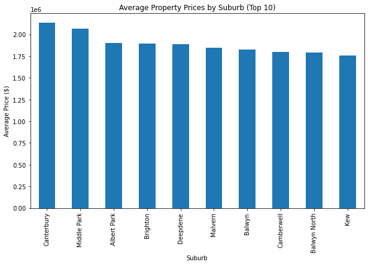

```python
# Group the data by suburb and calculate the mean property price for each suburb
suburb_data = data.groupby('Suburb')['Price'].mean().sort_values(ascending=False)

# Print the top 10 suburbs with the highest average property prices
print('Top 10 suburbs with highest average property prices:\n', suburb_data.head(10))

# Visualize the average property prices by suburb using a bar chart
suburb_data.head(10).plot(kind='bar', figsize=(10, 6))
plt.title('Average Property Prices by Suburb (Top 10)')
plt.xlabel('Suburb')
plt.ylabel('Average Price ($)')
plt.show()
```

1. Which types of houses are more in melbourne?

```
Type
h    23978
t     3578
u     7294
dtype: int64
```

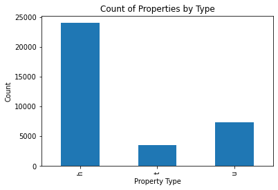

```python
property = data.groupby('Type')#grouping data based on the type of the property
property_counts = property.size()#counting them together based on type which got in 1st step
print(property_counts)
# Plot the counts of each property type
fig, ax = plt.subplots()
property_counts.plot(kind='bar')
ax.set_xlabel('Property Type')
ax.set_ylabel('Count')
ax.set_title('Count of Properties by Type')
plt.show()
```

There are more 'h' type of houses in melbourne its about 23978 and next comes the 'u' type with with7294 in count and last is the 't' type 3578 in count

1. Are there any patterns or trends in the type of properties that are being bought or sold in Melbourne?

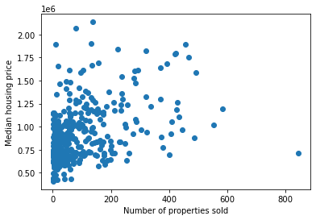

```
              Suburb  SalesCount      Price
171    Hopetoun Park           1 435747.340
92   Cranbourne East           1 440000.000
179         Kalkallo           1 615000.000
346       Yarra Glen           1 620000.000
87        Coldstream           1 630000.000
             Suburb  SalesCount       Price
264       Reservoir         844  711946.978
32   Bentleigh East         583 1193510.851
265        Richmond         552 1022277.014
149       Glen Iris         491 1587272.588
261         Preston         485  880732.164
```

```python
# Group data by suburb and count number of properties sold
sales_by_suburb = data.groupby('Suburb')['Price'].count().reset_index()
sales_by_suburb = sales_by_suburb.rename(columns={'Price': 'SalesCount'})

# Calculate mean price for each suburb
mean_price_by_suburb = data.groupby('Suburb')['Price'].mean().reset_index()

# Merge mean price with sales count
sales_by_suburb = pd.merge(sales_by_suburb, mean_price_by_suburb, on='Suburb')

# Visualize data with scatter plot
plt.scatter(sales_by_suburb['SalesCount'], sales_by_suburb['Price'])
plt.xlabel('Number of properties sold')
plt.ylabel('Median housing price')
plt.show()

# Suburbs with highest sales and lowest median price
print(sales_by_suburb.sort_values(by=['SalesCount', 'Price']).head())

# Suburbs with lowest sales and highest median price
print(sales_by_suburb.sort_values(by=['SalesCount', 'Price'], ascending=[False, False]).head())
```

1. How do housing prices in Melbourne vary by year?

```python
# Extract the year and month from the Date column
data['Year'] = data['Date'].dt.year
data['Month'] = data['Date'].dt.month

# Group the data by year and month, and calculate the median price
price_by_month = data.groupby(['Year'])['Price'].mean().reset_index()

# Print the median price for each month
print(price_by_month[['Year', 'Price']])
```

```
   Year       Price
0  2016 1101496.241
1  2017 1077483.234
2  2018 1042143.431
```

The average price has decreased year by year from 2016 to 2018 for the properties

1. who is the best seller in each year from 2016 to 2018?

```python
# Group the dataset by year and seller and count the number of sales
grouped = data.groupby(['Year', 'SellerG']).size().reset_index(name='Sales')

# Sort the dataframe by year and sales in descending order
sorted_df = grouped.sort_values(['Year', 'Sales'], ascending=[True, False])

# Select the top seller for the desired year (e.g., 2018)
top_seller = sorted_df.loc[sorted_df['Year'] == 2018]['SellerG'].iloc[0]

print(f"The top seller in 2018 was {top_seller}.")
```

```
The top seller in 2018 was Barry.
```

The top seller in 2018 was Barry.

1. which type of houses in melbourne cost more and less?

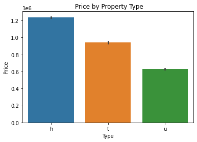

```python
# Check the  price of each property type
sns.barplot(x='Type', y='Price', data=data, order=['h', 't', 'u'])
plt.title(' Price by Property Type')
plt.show()
```

As expected 'h' type cost more as it will be near to suburbs then the 't' types as the square meters will be more and last the u type cost less.

1. how does price of the property depend on the distance?

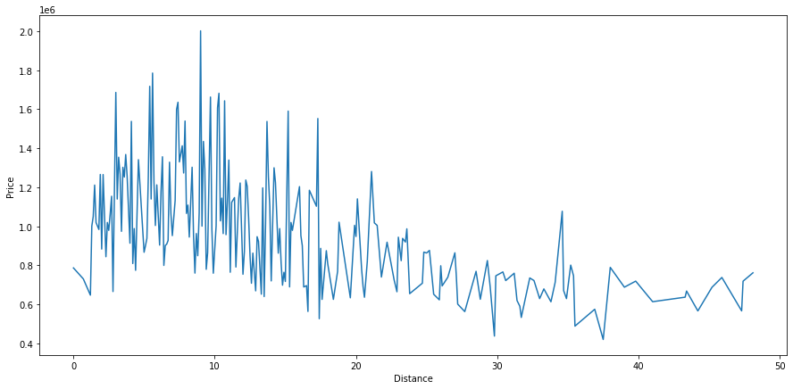

|  | Distance | Price |
| --- | --- | --- |
| 0 | 10.500 | 11200000.000 |
| 1 | 18.800 | 9000000.000 |
| 2 | 9.000 | 8000000.000 |
| 3 | 5.300 | 7650000.000 |
| 4 | 6.300 | 7000000.000 |
| ... | ... | ... |
| 210 | 33.000 | 630000.000 |
| 211 | 33.800 | 630000.000 |
| 212 | 31.400 | 620000.000 |
| 213 | 35.500 | 601000.000 |
| 214 | 37.500 | 545000.000 |

215 rows × 2 columns

```python
# Create a line plot of distance versus price
plt.figure(figsize=(15,7))
sns.lineplot(data=data, x='Distance', y ='Price',ci=None)
plt.show()
data.groupby(['Distance'])['Price'].max().sort_values(ascending = False).reset_index()
```

```python
Per_price=data.loc[data['Price']>1000000,'Price'].count()/data['Price'].count()
Per_price = Per_price*100
Per_price
```

```
40.72883787661406
```

# implementation of classes and functions

```python
class MelbourneHousingDataset:
    def __init__(self, filepath):
        self.data = pd.read_csv(filepath)

    def filter_by_rooms(self, min_room, max_room):
        return self.data[(self.data['Rooms'] >= min_room) & (self.data['Rooms'] <= max_room)]

def main():
    # Create a MelbourneHousingDataset object
    dataset = MelbourneHousingDataset('C:/Users/Anagha/Downloads/archive (4)/Melbourne_housing_FULL.csv')
    # Filter the dataset by price
    filtered_data = dataset.filter_by_rooms(5, 7)
    # Print the first five rows of the filtered dataset
    print(filtered_data.head())
#calling main function
if __name__ == '__main__':
    main()
```

```
           Suburb           Address  Rooms Type       Price Method  \
76   Airport West       33 Bowes Av      5    h 1035000.000      S
81   Airport West  11 Harrington Rd      6    h  725000.000     SP
96   Airport West      241 Parer Rd      5    h  755000.000     PI
153   Albert Park      23 Finlay St      5    h 2100000.000      S
175   Albert Park    143 Kerferd Rd      7    h         NaN     SN

           SellerG        Date  Distance  Postcode  ...  Bathroom   Car  \
76         Airport   6/08/2016    13.500  3042.000  ...       NaN   NaN
81           Barry   7/05/2016    13.500  3042.000  ...     3.000 2.000
96      Propertyau  14/05/2016    13.500  3042.000  ...     2.000 2.000
153           Greg  10/12/2016     3.300  3206.000  ...     2.000 1.000
175  hockingstuart  24/09/2016     3.300  3206.000  ...     7.000 0.000

     Landsize  BuildingArea  YearBuilt                 CouncilArea Lattitude  \
76        NaN           NaN        NaN  Moonee Valley City Council       NaN
81    976.000       186.000   1980.000  Moonee Valley City Council   -37.724
96    596.000           NaN        NaN  Moonee Valley City Council   -37.725
153   237.000           NaN        NaN   Port Phillip City Council   -37.844
175   435.000           NaN        NaN   Port Phillip City Council   -37.847

     Longtitude             Regionname Propertycount
76          NaN   Western Metropolitan      3464.000
81      144.874   Western Metropolitan      3464.000
96      144.870   Western Metropolitan      3464.000
153     144.956  Southern Metropolitan      3280.000
175     144.954  Southern Metropolitan      3280.000

[5 rows x 21 columns]
```

# Business Insights:

1. There are 34857 rows and 21 columns in the dataset 2.Highest number of the properties are in Reservoir suburb followed by properties in Bentleigh East suburb.
2. Most of the properties are of type 'h' that is houses/cottages/villas hence company should focus more on 'h' type of property for selling to customers as it is more.
3. Top 5 sellers of properties are - Jellis,Nelson, Barry, hockingstuart, and marshall, hence the company should focus on them while buying the properties.
4. The distance of the property from the key facilities play a cruicial role in deciding the selling price of a property.Therefore the properties which are near to center cost more.
5. The people are interested more in the vintage properties hence the prices of the properties which are older has more price.
6. Suburb with highest average price is Canterbury Suburb with lowest average price is Darley, so the investors can keep this in mind while investing in the properties if the price is main criterion.
7. There are more 'h' type of houses than 't' and 'u' hence the customers might have more option for h type houses.
8. The main factor for increase in the price is distance if the distance is less from central then price of propert is more.
9. The 'h' type houses cost more compared to other types.
10. if the property is within 15km from CBD the price is more hence the customers should keep in mind while buying or selling the property.